# Forecasting Monthly Natural Gas Prices in the US through Various Forecasting Techniques

Jana Patricia Lumontod | Melyssa Villaflores | Nicole Kyte Villamor

2024-06-07

# 1 | Introduction

Natural gas is a crucial source of energy and is increasingly being recognized as a cleaner alternative to coal and oil for electricity generation in many countries [1]. In addition, it is widely used in homes for cooking and heating purposes and is an important fuel in industrial processes. As such, it would be greatly beneficial for stakeholders, the energy sector, policymakers, and consumers for an effective approach for forecasting natural gas prices to be developed. It could help in making informed decisions, managing business risks, and optimizing industrial operations.

Forecasting natural gas prices, however, poses several challenges and complexities. One of its main difficulties lies in the volatility of natural gas markets, which is influenced by factors such as geopolitical events, weather patterns (temperatures), economic conditions and other external factors affecting its supply and demand [2]. In the context of the Philippines, the challenge is made harder by the limited availability of records, which only cover less than a decade of data. Therefore, this project will mainly focus on exploring univariate time-series forecasting models, leveraging available historical data from the U.S. on natural gas prices.

Specifically, the project will explore and compare several types of time-series forecasting models, namely: a naïve model, exponential smoothing models, and the Autoregressive Integrated Moving-Average (ARIMA) model. Given the lack of local records, it will instead make use of U.S. data from January 1997 to August 2020, sourced from the U.S. Energy Information Administration (EIA), which recorded nominal monthly natural gas prices in dollars per million British thermal units (MMBtu). The results from this analysis aim to give insight into the dynamics of natural gas prices, and a foundation for forecasting methods that can be adapted to local Philippine data once it becomes more available.

## 1.1 | Objectives

The objective of this study is to apply naïve forecasting, exponential smoothing, and ARIMA models to forecast monthly natural gas prices using data from the US and compare their performances to determine which model is better. The data will be split into the training set and test set, and the latter will be used to measure the model’s accuracy and determine which model is best.

## 1.2 | Scope and Delimitations

This study focuses on utilizing univariate time-series forecasting models in order to analyze data on monthly U.S. natural gas prices from January 1997 to December 2019. Thus, this study does not aim to explore multivariate and explanatory forecasting models. Furthermore, in order to more efficiently build a robust forecasting model, a U.S. dataset is used due to the abundance of readily available U.S.records. As such, this study’s methods will be focusing on working with U.S. data as a starting point for model development. Future studies may expand and explore on the application of the model to local contexts once data on natural gas prices becomes available.

## 1.3 | Significance

Forecasting accurate prices of natural gas is significant for several reasons. First, this study may aid the government agencies in formulating policies and economic planning. Businesses can use this study for budgeting, investing, and in managing the cost of production. Second, accurate forecasts may benefit the consumers from financial planning and properly budgeting their energy expenses. Hence, the findings of this study provide significant insights that may be used for decision-making in various fields.

# 2 | Methods

Data on gas prices was downloaded through [Kaggle](https://www.kaggle.com/datasets/joebeachcapital/natural-gas-prices), an online repository. The chosen dataset contained monthly records of natural gas prices in the United States of America (USA). The prices were measured in nominal US Dollars (USD), and the data spanned from January 1997 to August 2020.

## 2.1 | Data preprocessing

The dataset was made available using a .csv file, consisting of natural gas prices per month-year.

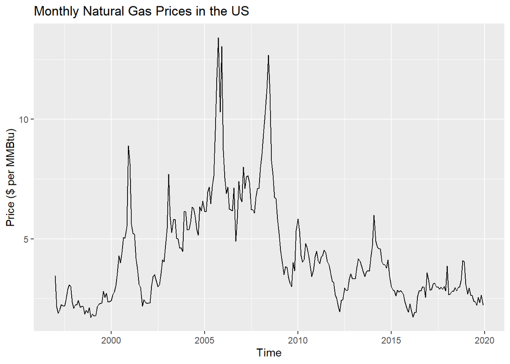

The dataset contained a total of 284 data points, and the dates were recorded in the format YYYY-mm. Due to the incomplete data in 2020 where records were only available until August 2020, the last 8 data points were removed from the time series altogether, reducing the number of data points to 276. The data was then split into two sets: the training set with 216 data points from January 1997 to December 2014, and the test set with 60 data points from January 2015 to December 2019. An assumption was made regarding the data spike somewhere between 2003 and 2013, where these points were not considered as outliers but rather explainable by real-world events. Thus, the authors proceeded with the time series analysis.

## 2.2 | Feature construction and selection

Based on the plot shown above, the data suggests non-stationarity due to the distinct peaking trend observed between 2003 to 2013. Furthermore, there seems to be no distinct seasonality or cycles.

For a more detailed analysis, the time series was plotted using a seasonal plot and decomposed using the `stlplus()` function in R.

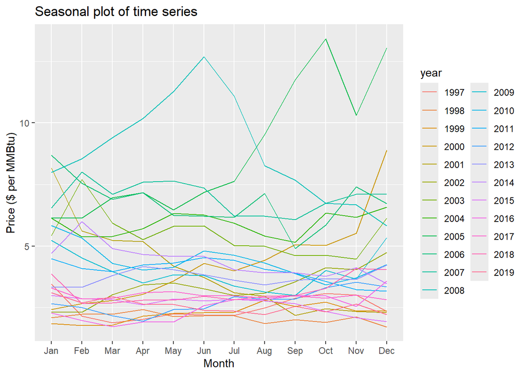

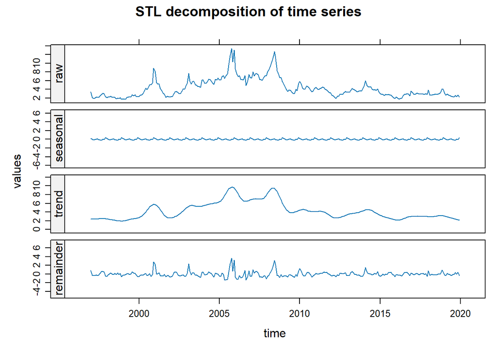

The seasonal plot indicates little to no seasonality due to the absence of identifiable monthly patterns. This is supported by the STL decomposition plot, which shows very weak seasonality and a non-monotonic trend.

## 2.3 | Model training

Four (4) major forecasting methods were chosen to be applied to the data: (a) Naïve forecasting, (b) Exponential smoothing, (c) ARIMA models, and (d) Holt’s methods. For all methods, the models were trained using the data in `training.set`, and the forecasting horizon was set to `h=60`, corresponding to the number of data points in the test set.

### 2.3.a Naïve forecasting

Naïve forecasting takes the most recent observation in the training set and uses it as the forecast for all future values.

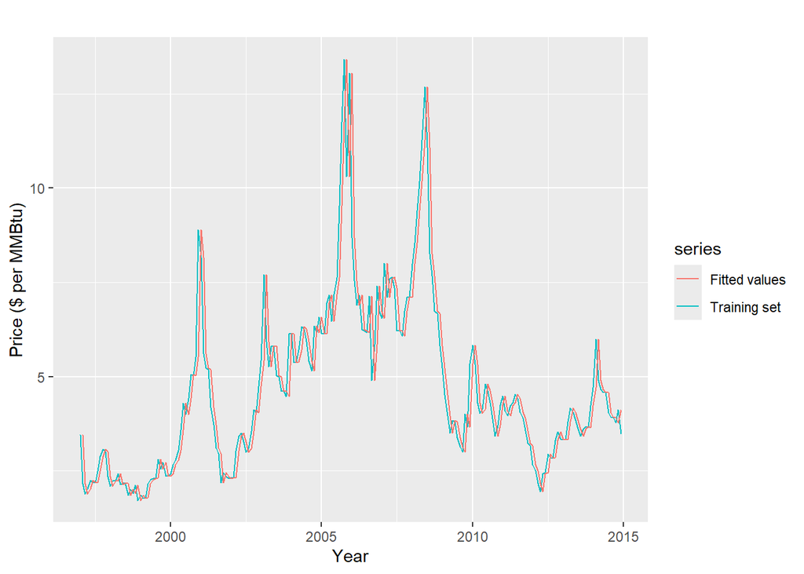

### 2.3.b Exponential smoothing

Two methods were chosen from the exponential smoothing group: simple exponential smoothing (SES) and error-trend-seasonality (ETS) model.

#### i. Simple exponential smoothing

Since it was established that the data has no clear trend or seasonality pattern, simple exponential smoothing was considered as a forecasting model.

```
##
## Forecast method: Simple exponential smoothing
##
## Model Information:
## Simple exponential smoothing
##
## Call:
##  ses(y = training.set, h = 60)
##
##   Smoothing parameters:
##     alpha = 0.9758
##
##   Initial states:
##     l = 3.4192
##
##   sigma:  0.825
##
##      AIC     AICc      BIC
## 1081.968 1082.082 1092.094
##
## Error measures:
##                        ME     RMSE       MAE        MPE     MAPE     MASE
## Training set 0.0003608785 0.821214 0.5190059 -0.9359645 10.23667 0.311954
##                       ACF1
## Training set -0.0006727868
##
## Forecasts:
##          Point Forecast       Lo 80     Hi 80       Lo 95     Hi 95
## Jan 2015       3.495263  2.43792865  4.552598  1.87820956  5.112317
## Feb 2015       3.495263  2.01791586  4.972610  1.23585543  5.754671
## Mar 2015       3.495263  1.69327708  5.297249  0.73936327  6.251163
## Apr 2015       3.495263  1.41878716  5.571739  0.31956715  6.670959
## May 2015       3.495263  1.17656711  5.813959 -0.05087644  7.041403
## Jun 2015       3.495263  0.95736045  6.033166 -0.38612409  7.376650
## Jul 2015       3.495263  0.75563747  6.234889 -0.69463277  7.685159
## Aug 2015       3.495263  0.56778170  6.422745 -0.98193338  7.972460
## Sep 2015       3.495263  0.39127436  6.599252 -1.25187807  8.242404
## Oct 2015       3.495263  0.22427779  6.766249 -1.50727727  8.497804
## Nov 2015       3.495263  0.06540252  6.925124 -1.75025604  8.740782
## Dec 2015       3.495263 -0.08643236  7.076959 -1.98246745  8.972994
```

[output cut: 33 more lines]

```
## Oct 2018       3.495263 -3.50651528 10.497042 -7.21303291 14.203559
## Nov 2018       3.495263 -3.58213044 10.572657 -7.32867631 14.319203
## Dec 2018       3.495263 -3.65694621 10.647473 -7.44309716 14.433624
## Jan 2019       3.495263 -3.73098744 10.721514 -7.55633344 14.546860
## Feb 2019       3.495263 -3.80427768 10.794804 -7.66842120 14.658948
## Mar 2019       3.495263 -3.87683934 10.867366 -7.77939468 14.769921
## Apr 2019       3.495263 -3.94869372 10.939220 -7.88928647 14.879813
## May 2019       3.495263 -4.01986111 11.010387 -7.99812760 14.988654
## Jun 2019       3.495263 -4.09036085 11.080887 -8.10594765 15.096474
## Jul 2019       3.495263 -4.16021138 11.150738 -8.21277481 15.203301
## Aug 2019       3.495263 -4.22943031 11.219957 -8.31863603 15.309162
## Sep 2019       3.495263 -4.29803447 11.288561 -8.42355704 15.414083
## Oct 2019       3.495263 -4.36603996 11.356566 -8.52756246 15.518089
## Nov 2019       3.495263 -4.43346218 11.423989 -8.63067585 15.621202
## Dec 2019       3.495263 -4.50031589 11.490842 -8.73291977 15.723446
```

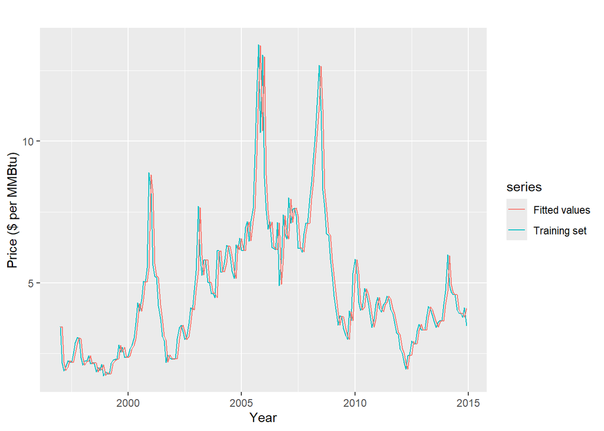

Model details gave the parameter values of `alpha = 0.9758` and initial level `l_0 = 3.4192`. The alpha value being close to 1 suggests that the SES forecast tends towards the naive method.

#### ii. Error-trend-seasonality (ETS) model

The ETS model type was automatically selected using the `ets()` function.

```
## ETS(M,N,N)
##
## Call:
##  ets(y = training.set)
##
##   Smoothing parameters:
##     alpha = 0.9999
##
##   Initial states:
##     l = 3.3785
##
##   sigma:  0.1382
##
##      AIC     AICc      BIC
## 931.6117 931.7249 941.7375
##
## Training set error measures:
##                        ME      RMSE       MAE        MPE     MAPE      MASE
## Training set 0.0004701376 0.8214758 0.5167761 -0.9071822 10.19189 0.3106138
##                     ACF1
## Training set -0.02576836
```

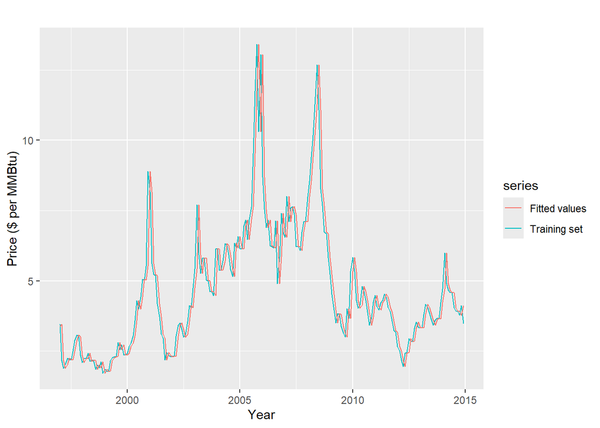

The `ets()` function selected an ETS model with multiplicative error and no trend or seasonality.

### 2.3.c ARIMA models

Upon inspection of the time series plot, it is apparent that the data is not (trend) stationary. Thus, the Augmented Dickey-Fuller (ADF) test and Kwiatkowski-Phillips-Schmidt-Shin (KPSS) test were used to verify non-stationarity.

```
##
##  Augmented Dickey-Fuller Test
##
## data:  training.set
## Dickey-Fuller = -2.5865, Lag order = 5, p-value = 0.33
## alternative hypothesis: stationary
```

```
##
##  KPSS Test for Trend Stationarity
##
## data:  training.set
## KPSS Trend = 0.67293, Truncation lag parameter = 4, p-value = 0.01
```

Test results show that the data was not stationary, with a suggested lag order of 5 from the ADF test. First-order differencing was applied, and the differenced data was subjected to the stationarity tests.

```
##
##  Augmented Dickey-Fuller Test
##
## data:  gas.ts.d1
## Dickey-Fuller = -6.1784, Lag order = 5, p-value = 0.01
## alternative hypothesis: stationary
```

```
##
##  KPSS Test for Trend Stationarity
##
## data:  gas.ts.d1
## KPSS Trend = 0.026715, Truncation lag parameter = 4, p-value = 0.1
```

Test results show that the data is now stationary. Thus, the initial ARIMA models to be considered were of the order ARIMA(p,1,q). The ACF and PACF plots were inspected for possible values of p and q.

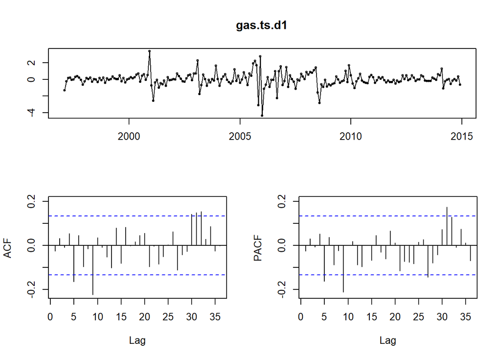

Significant spikes were present at AR(5) and MA(5). Various combinations of p and q were tested, along with a trial model of AR(1) and MA(1).

```
## Series: training.set
## ARIMA(5,1,5)
##
## Coefficients:
##          ar1     ar2     ar3     ar4      ar5      ma1      ma2      ma3
##       0.5510  0.0667  0.1159  0.7263  -0.7198  -0.5981  -0.0138  -0.1604
## s.e.  0.3573  0.1104  0.0907  0.0751   0.3151   0.4153   0.1081   0.1207
##           ma4     ma5
##       -0.7360  0.6192
## s.e.   0.0962  0.4089
##
## sigma^2 = 0.6414:  log likelihood = -252.78
## AIC=527.57   AICc=528.87   BIC=564.64
```

```
## Series: training.set
## ARIMA(5,1,1)
##
## Coefficients:
##           ar1     ar2     ar3     ar4      ar5     ma1
##       -0.7558  0.0109  0.0199  0.0444  -0.0891  0.7694
## s.e.   0.1852  0.0857  0.0855  0.0852   0.0827  0.1772
##
## sigma^2 = 0.6672:  log likelihood = -258.66
## AIC=531.32   AICc=531.86   BIC=554.91
```

```
## Series: training.set
## ARIMA(1,1,5)
##
## Coefficients:
##           ar1     ma1     ma2     ma3     ma4      ma5
##       -0.8838  0.8875  0.0104  0.0238  0.0343  -0.0741
## s.e.   0.1253  0.1496  0.0941  0.1000  0.1057   0.0978
##
## sigma^2 = 0.6684:  log likelihood = -258.85
## AIC=531.69   AICc=532.23   BIC=555.29
```

```
## Series: training.set
## ARIMA(1,1,1)
##
## Coefficients:
##           ar1     ma1
##       -0.9789  0.9470
## s.e.   0.0265  0.0439
##
## sigma^2 = 0.6646:  log likelihood = -260.26
## AIC=526.52   AICc=526.63   BIC=536.63
```

Out of the 4 candidate ARIMA models, the model with order ARIMA(1,1,1) produced the lowest AICc score of 526.63, making it the best choice of ARIMA model. The model was fitted to the training set to visually inspect goodness-of-fit.

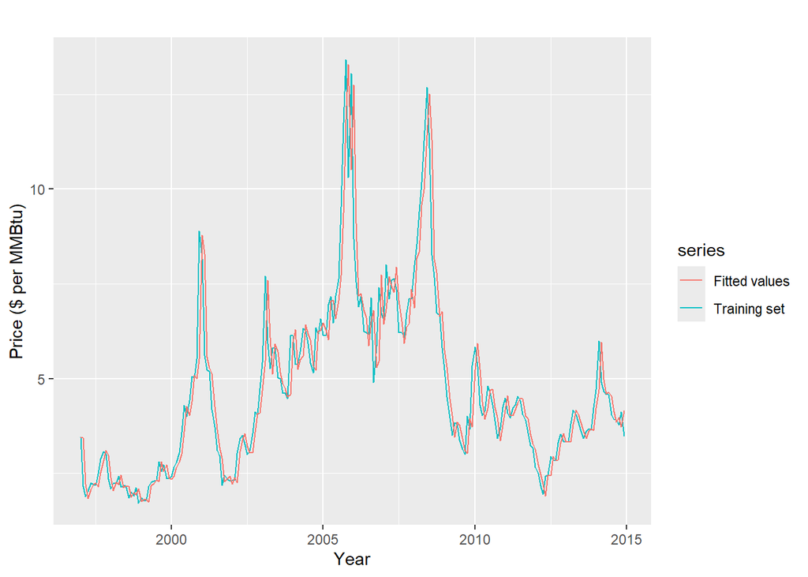

Upon consultation with the adviser, the authors considered the order ARIMA(1,0,1), which suggests an ARIMA model with no differencing contrary to the results of the stationarity tests.

```
## Series: training.set
## ARIMA(1,0,1) with non-zero mean
##
## Coefficients:
##          ar1     ma1    mean
##       0.9309  0.0074  4.5590
## s.e.  0.0252  0.0687  0.7577
##
## sigma^2 = 0.6628:  log likelihood = -261.58
## AIC=531.15   AICc=531.34   BIC=544.65
```

The AICc value is 531.34, which indicates that ARIMA(1,1,1) is still the better model. For the sake of further analysis, the ARIMA(1,0,1) model will later be used to forecast values in the test set and compared with ARIMA(1,1,1).

### 2.3.d Holt’s methods

Holt’s forecasting methods are technically under exponential smoothing, but the authors decided to separate this group because the methods incorporate trend and seasonality into the forecasts. Three methods were tested: Holt’s linear trend, Holt-Winters additive, and Holt-Winters additive damped. All models were fitted to the training set to visually inspect goodness-of-fit.

#### i. Holt’s linear trend method

This method incorporates trend into the forecasting model.

```
##
## Forecast method: Holt's method
##
## Model Information:
## Holt's method
##
## Call:
##  holt(y = training.set, h = 60)
##
##   Smoothing parameters:
##     alpha = 0.9913
##     beta  = 1e-04
##
##   Initial states:
##     l = 2.6117
##     b = -3e-04
##
##   sigma:  0.831
##
##      AIC     AICc      BIC
## 1087.056 1087.341 1103.932
##
## Error measures:
##                       ME      RMSE       MAE        MPE     MAPE      MASE
## Training set 0.004187393 0.8232834 0.5211858 -0.8058945 10.31199 0.3132643
##                     ACF1
## Training set -0.02361299
##
## Forecasts:
##          Point Forecast       Lo 80     Hi 80      Lo 95     Hi 95
## Jan 2015       3.485337  2.42034967  4.550324  1.8565795  5.114094
## Feb 2015       3.485111  1.98547975  4.984743  1.1916228  5.778600
## Mar 2015       3.484886  1.65081460  5.318956  0.6799161  6.289855
## Apr 2015       3.484660  1.36830385  5.601016  0.2479726  6.721347
## May 2015       3.484434  1.11919967  5.849669 -0.1328799  7.101748
## Jun 2015       3.484209  0.89385510  6.074562 -0.4773952  7.445812
## Jul 2015       3.483983  0.68652822  6.281437 -0.7943548  7.762321
## Aug 2015       3.483757  0.49347309  6.474041 -1.0894877  8.057002
## Sep 2015       3.483532  0.31208538  6.654978 -1.3667768  8.333840
## Oct 2015       3.483306  0.14046765  6.826144 -1.6291240  8.595736
```

[output cut: 35 more lines]

```
## Oct 2018       3.475182 -3.70245940 10.652823 -7.5020731 14.452436
## Nov 2018       3.474956 -3.78061919 10.730531 -7.6214887 14.571401
## Dec 2018       3.474730 -3.85796613 10.807427 -7.7396612 14.689122
## Jan 2019       3.474505 -3.93452559 10.883535 -7.8566293 14.805639
## Feb 2019       3.474279 -4.01032168 10.958880 -7.9724299 14.920988
## Mar 2019       3.474053 -4.08537728 11.033484 -8.0870981 15.035205
## Apr 2019       3.473828 -4.15971418 11.107370 -8.2006671 15.148322
## May 2019       3.473602 -4.23335312 11.180557 -8.3131687 15.260373
## Jun 2019       3.473376 -4.30631384 11.253066 -8.4246330 15.371386
## Jul 2019       3.473151 -4.37861521 11.324917 -8.5350890 15.481390
## Aug 2019       3.472925 -4.45027521 11.396125 -8.6445640 15.590414
## Sep 2019       3.472699 -4.52131105 11.466710 -8.7530845 15.698483
## Oct 2019       3.472474 -4.59173916 11.536686 -8.8606756 15.805623
## Nov 2019       3.472248 -4.66157529 11.606071 -8.9673612 15.911857
## Dec 2019       3.472022 -4.73083450 11.674879 -9.0731646 16.017209
```

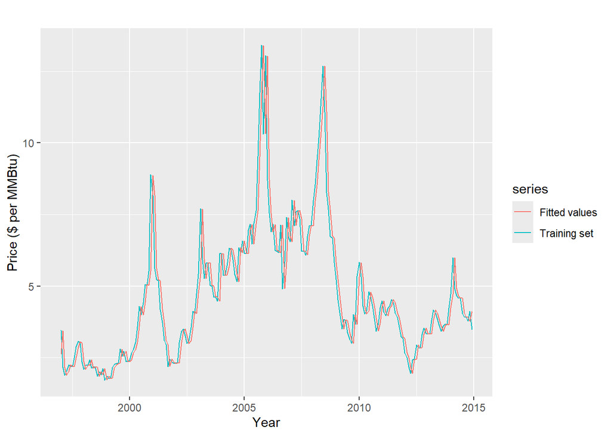

#### ii. Holt-Winters additive method

This method incorporates trend and seasonality, setting the latter as additive since the variance of the time series does not seem to change over time.

```
##
## Forecast method: Holt-Winters' additive method
##
## Model Information:
## Holt-Winters' additive method
##
## Call:
##  hw(y = training.set, h = 60, seasonal = "additive", damped = FALSE)
##
##   Smoothing parameters:
##     alpha = 0.9914
##     beta  = 0.0024
##     gamma = 1e-04
##
##   Initial states:
##     l = 2.1465
##     b = 0.006
##     s = 0.5213 0.031 0.0544 -0.2998 -0.2948 -0.2942
##            0.0047 -0.0661 -0.0583 -0.0895 0.1735 0.3179
##
##   sigma:  0.83
##
##      AIC     AICc      BIC
## 1097.956 1101.047 1155.336
##
## Error measures:
##                        ME      RMSE       MAE        MPE     MAPE     MASE
## Training set -0.005837882 0.7986935 0.5255526 -0.9426642 10.99233 0.315889
##                    ACF1
## Training set 0.00291752
##
## Forecasts:
##          Point Forecast      Lo 80     Hi 80        Lo 95     Hi 95
## Jan 2015       3.289177  2.2254549  4.352899   1.66235449  4.915999
## Feb 2015       3.147699  1.6480035  4.647395   0.85411237  5.441286
## Mar 2015       2.887625  1.0512828  4.723967   0.07918209  5.696067
## Apr 2015       2.921732  0.8002444  5.043219  -0.32280319  6.166267
## May 2015       2.916789  0.5430215  5.290556  -0.71357512  6.547153
## Jun 2015       2.990470  0.3877103  5.593229  -0.99010723  6.971046
## Jul 2015       2.694315 -0.1198410  5.508471  -1.60956516  6.998195
```

[output cut: 38 more lines]

```
## Oct 2018       3.155544 -4.3968608 10.707949  -8.39486249 14.705951
## Nov 2018       3.134989 -4.5080646 10.778043  -8.55405288 14.824031
## Dec 2018       3.628275 -4.1047583 11.361308  -8.19837889 15.454929
## Jan 2019       3.427816 -4.3945679 11.250199  -8.53548769 15.391119
## Feb 2019       3.286338 -4.6247568 11.197433  -8.81263756 15.385314
## Mar 2019       3.026264 -4.9729419 11.025469  -9.20746556 15.259993
## Apr 2019       3.060371 -5.0263648 11.147106  -9.30722385 15.427965
## May 2019       3.055428 -5.1182762 11.229132  -9.44517374 15.556030
## Jun 2019       3.129109 -5.1310217 11.389239  -9.50367052 15.761888
## Jul 2019       2.832954 -5.5130777 11.178985  -9.93119988 15.597107
## Aug 2019       2.835214 -5.5962110 11.266638 -10.05953763 15.729965
## Sep 2019       2.833037 -5.6832888 11.349363 -10.19155935 15.857633
## Oct 2019       3.190204 -5.4105464 11.790954  -9.96350861 16.343917
## Nov 2019       3.169649 -5.5150639 11.854362 -10.11247325 16.451771
## Dec 2019       3.662935 -5.1052927 12.431162  -9.74691200 17.072782
```

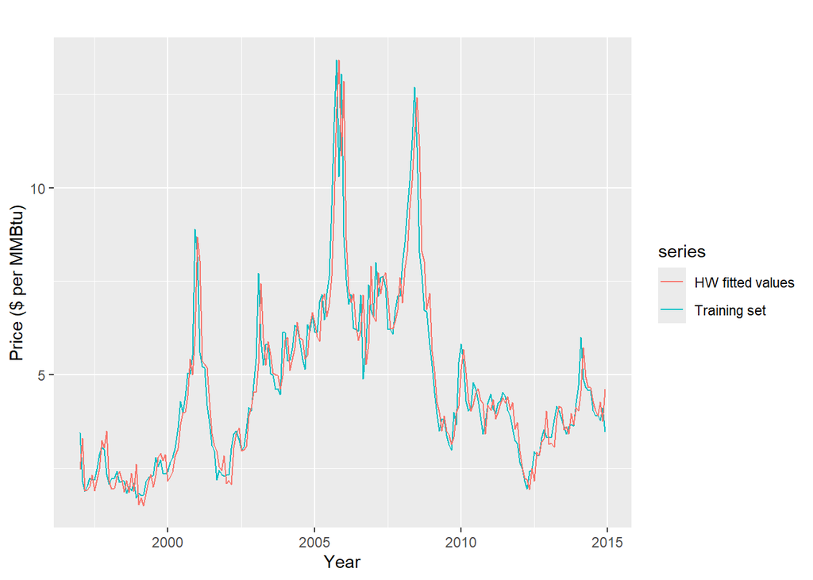

#### iii. Holt-Winters additive damped method

This method incorporates trend and additive seasonality. Additionally, the effect of the trend component is dampened as observations are taken further into the past.

```
##
## Forecast method: Damped Holt-Winters' additive method
##
## Model Information:
## Damped Holt-Winters' additive method
##
## Call:
##  hw(y = training.set, h = 60, seasonal = "additive", damped = TRUE)
##
##   Smoothing parameters:
##     alpha = 0.9828
##     beta  = 0.0024
##     gamma = 1e-04
##     phi   = 0.8789
##
##   Initial states:
##     l = 2.2904
##     b = -0.3731
##     s = 0.4748 -0.0082 -0.0083 -0.2568 -0.2279 -0.2028
##            0.1404 0.0034 -0.0754 -0.1543 0.0863 0.2289
##
##   sigma:  0.8316
##
##      AIC     AICc      BIC
## 1099.706 1103.178 1160.461
##
## Error measures:
##                      ME      RMSE       MAE        MPE     MAPE     MASE
## Training set 0.01584666 0.7982306 0.5279134 -0.2049597 11.08618 0.317308
##                     ACF1
## Training set 0.008185211
##
## Forecasts:
##          Point Forecast       Lo 80     Hi 80       Lo 95     Hi 95
## Jan 2015       3.251049  2.18527621  4.316823  1.62108994  4.881009
## Feb 2015       3.106290  1.61044447  4.602135  0.81859175  5.393988
## Mar 2015       2.863792  1.03532049  4.692263  0.06738638  5.660197
## Apr 2015       2.941081  0.83095223  5.051210 -0.28608262  6.168245
## May 2015       3.018254  0.65919932  5.377309 -0.58960879  6.626117
## Jun 2015       3.154059  0.56940965  5.738708 -0.79882092  7.106938
```

[output cut: 39 more lines]

```
## Oct 2018       2.996144 -4.21191291 10.204202 -8.02762800 14.019917
## Nov 2018       2.996000 -4.29039368 10.282393 -8.14757734 14.139577
## Dec 2018       3.479082 -3.88481447 10.842979 -7.78302603 14.741191
## Jan 2019       3.233423 -4.20718754 10.674033 -8.14600874 14.612854
## Feb 2019       3.090797 -4.42572798 10.607323 -8.40473612 14.586331
## Mar 2019       2.850175 -4.74150699 10.441856 -8.76030053 14.460650
## Apr 2019       2.929113 -4.73698873 10.595215 -8.79517790 14.653404
## May 2019       3.007735 -4.73207202 10.747542 -8.82927827 14.844748
## Jun 2019       3.144813 -4.66800378 10.957630 -8.80385923 15.093485
## Jul 2019       2.801591 -5.08356080 10.686742 -9.25770776 14.860889
## Aug 2019       2.776406 -5.18042294 10.733234 -9.39251349 14.945325
## Sep 2019       2.747494 -5.28037145 10.775360 -9.53006694 15.025056
## Oct 2019       2.996103 -5.10217773 11.094383 -9.38914842 15.381354
## Nov 2019       2.995963 -5.17212515 11.164051 -9.49604981 15.487976
## Dec 2019       3.479050 -4.75825424 11.716355 -9.11881979 16.076920
```

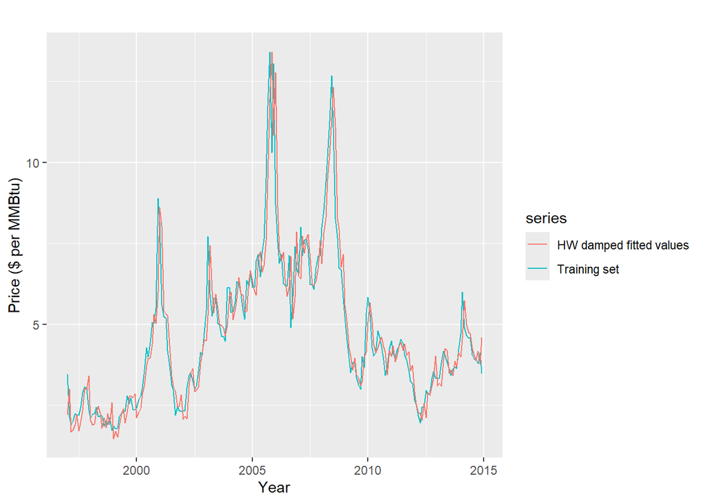

# 3 | Discussion

After the models have been trained with data from the training set, the models will be used to generate forecasts to be compared with the test set values to assess accuracy.

## 3.1 | Model comparison and validation

Each of the models produced by different forecasting methods were compared to choose the best model among them.

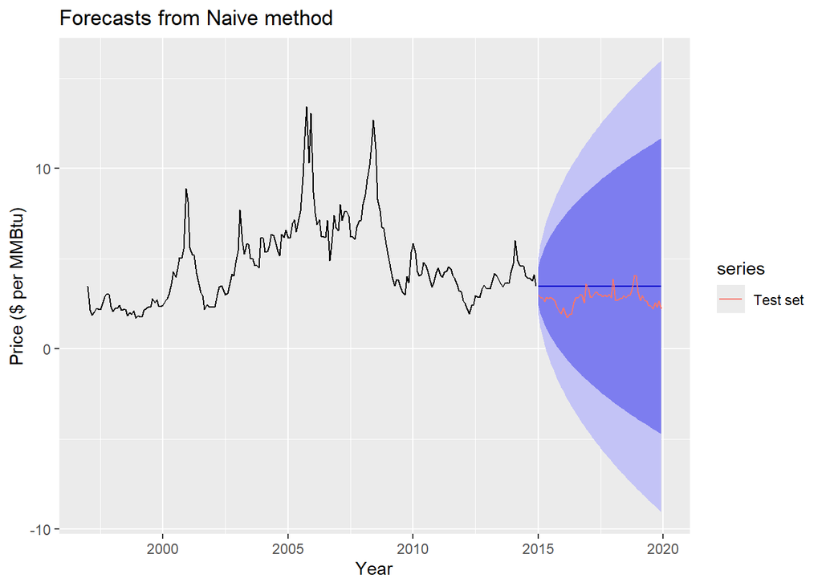

The naive method produces a flat line forecast using the last data point in the training set.

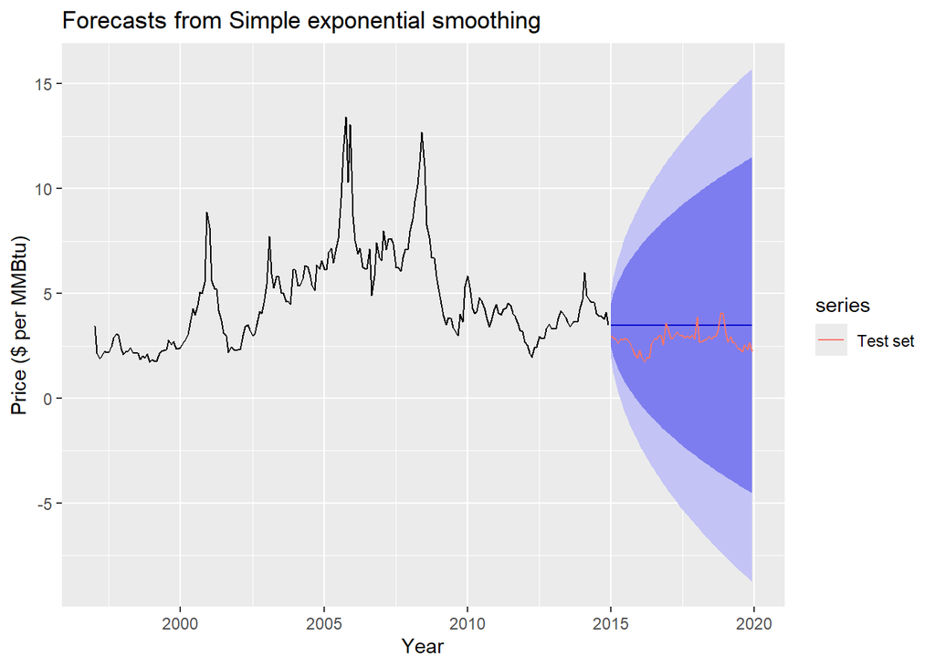

Similarly, since the SES tends towards the naive forecast model, it produced a flat line forecast.

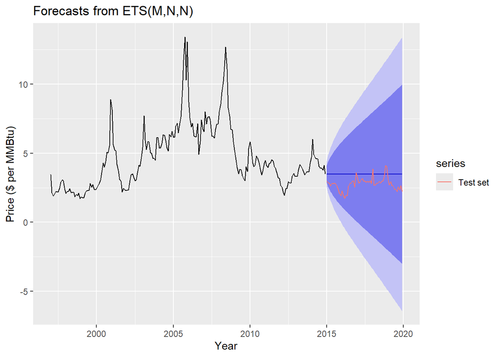

The ETS(M,N,N) model produced another flat line forecast, but the confidence interval is now smaller compared to the SES and naive forecasts.

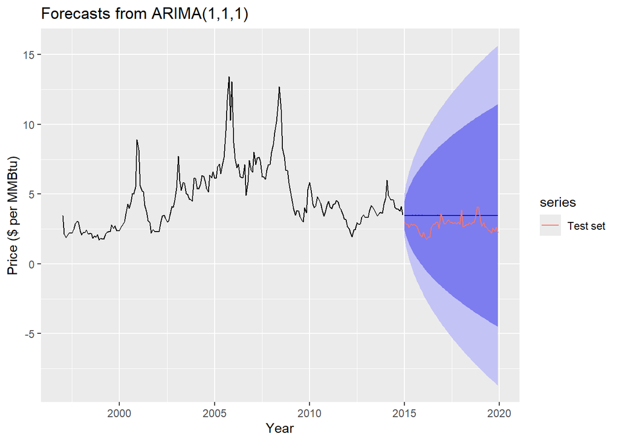

```
##                         ME      RMSE       MAE         MPE     MAPE      MASE
## Training set  0.0001205806 0.8095775 0.5187364  -0.9153452 10.29683 0.3117921
## Test set     -0.6990456328 0.8378359 0.7557730 -28.8531339 30.27730 0.4542655
##                    ACF1 Theil's U
## Training set 0.03616692        NA
## Test set     0.67161163  2.763072
```

The ARIMA model generated a flat line forecast, which is not ideal for practical forecasting. This may be explained by the time series having weak seasonality and a non-monotonic trend, so the data does not have enough distinguishable patterns for ARIMA to model from sufficiently.

The forecast generated by the ARIMA(1,0,1) model is seen below.

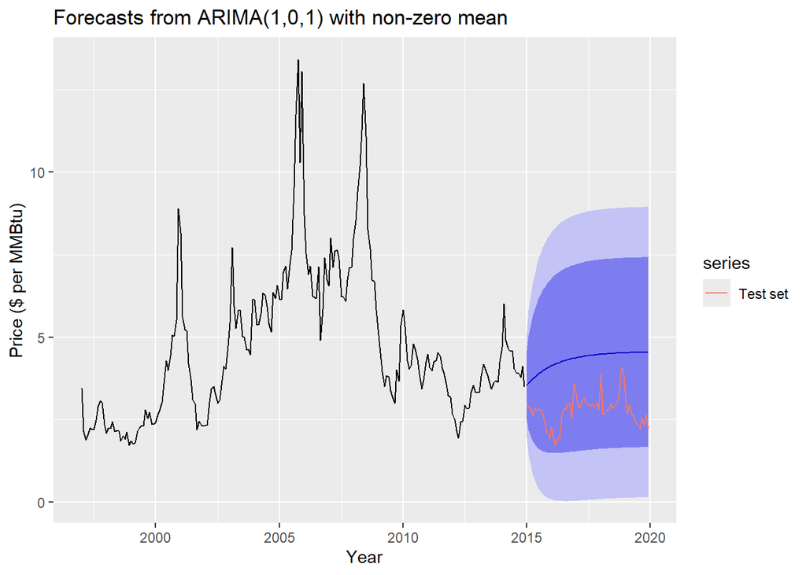

```
##                        ME      RMSE       MAE        MPE     MAPE      MASE
## Training set  0.007809923 0.8084525 0.5204099  -2.255175 10.49523 0.3127980
## Test set     -1.546145950 1.6200981 1.5461460 -59.975513 59.97551 0.9293276
##                    ACF1 Theil's U
## Training set 0.00596656        NA
## Test set     0.65665637  5.025605
```

One can observe a forecast with its level moving away from the test set as time progresses, which proves that this model is not viable to use for forecasting with this dataset.

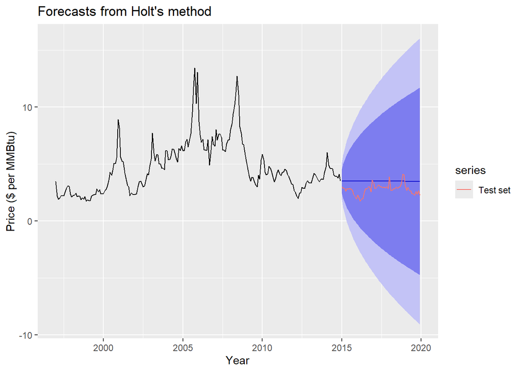

The Holt’s linear trend method produced a flat line forecast as expected of the non-monotonic and relatively level trend in the data.

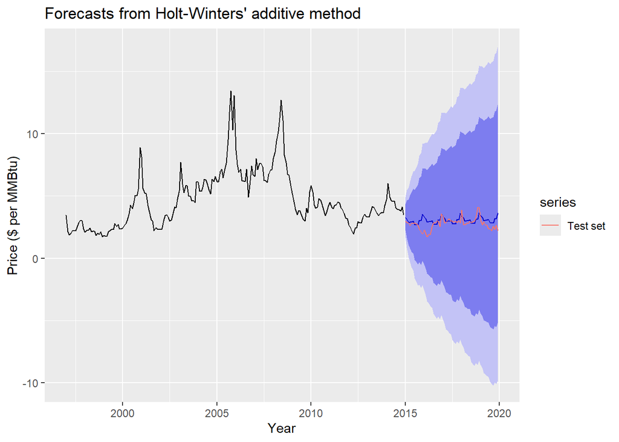

The Holt-Winters’ additive method attempted to capture the weak seasonality and trend, producing the following periodic forecast. The plot suggests that the forecast captured the three peaks near the end of the test set.

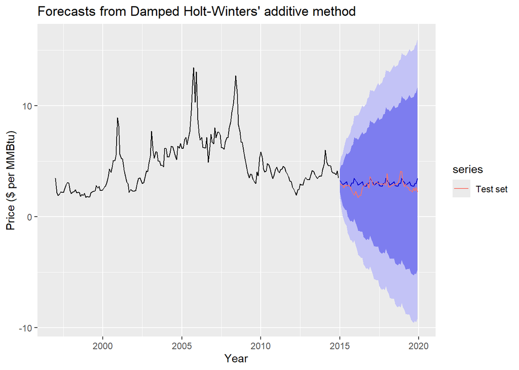

The Holt-Winters’ damped plot shows a smoother forecast, and similarly, it suggests that the forecast captured the three peaks near the end of the test set.

After plotting the models, error metrics were inspected to check for accuracy.

```
##                            RMSE       MAE       MPE     MAPE
## Naive                 0.8445768 0.7630000 -29.15904 30.55629
## SES                   0.8574003 0.7762281 -29.72553 31.07042
## ETS                   0.8446304 0.7630555 -29.16142 30.55844
## ARIMA                 0.8378359 0.7557730 -28.85313 30.27730
## Holt's linear trend   0.8438456 0.7621114 -29.11457 30.52254
## Holt-Winters additive 0.5611849 0.4135000 -13.32106 17.13749
## Holt-Winters damped   0.5321988 0.3852769 -11.53150 15.88157
```

It can be observed that Holt-Winters damped method has the lowest values in RMSE, MAE, MPE, and MAPE among other methods. Thus, Holt-Winters Damped method was chosen to be the best model.

The training set forecasts from the best models of each major model group are plotted into one graph. Notice that the ARIMA, naive, and SES models generate flat forecasts, while the Holt-Winters’ damped additive model generates a forecast close to the test set values.

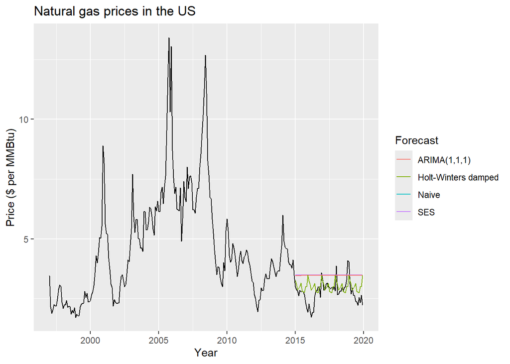

## 3.2 | Forecasting with best model

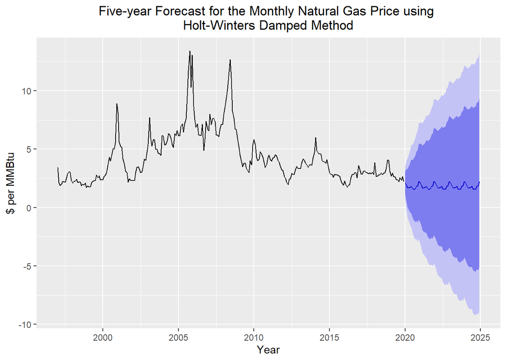

```
##
## Forecast method: Damped Holt-Winters' additive method
##
## Model Information:
## Damped Holt-Winters' additive method
##
## Call:
##  hw(y = gas.ts, h = 60, seasonal = "additive", damped = TRUE)
##
##   Smoothing parameters:
##     alpha = 0.9682
##     beta  = 5e-04
##     gamma = 1e-04
##     phi   = 0.8649
##
##   Initial states:
##     l = 2.7322
##     b = -0.414
##     s = 0.4417 0.0517 0.032 -0.2173 -0.224 -0.2066
##            0.0215 -0.0873 -0.1085 -0.1205 0.1173 0.3001
##
##   sigma:  0.7519
##
##      AIC     AICc      BIC
## 1412.273 1414.934 1477.440
##
## Error measures:
##                       ME      RMSE       MAE        MPE     MAPE      MASE
## Training set 0.006414625 0.7283651 0.4748716 -0.5557189 10.83753 0.3231835
##                     ACF1
## Training set 0.005410459
##
## Forecasts:
##          Point Forecast       Lo 80    Hi 80      Lo 95     Hi 95
## Jan 2020       2.103768  1.14018354 3.067353  0.6300926  3.577444
## Feb 2020       1.920744  0.57923387 3.262254 -0.1309186  3.972406
## Mar 2020       1.682729  0.04827384 3.317184 -0.8169545  4.182413
## Apr 2020       1.694526 -0.18797044 3.577023 -1.1845039  4.573556
## May 2020       1.715389 -0.38618704 3.816966 -1.4986943  4.929473
## Jun 2020       1.824011 -0.47596015 4.123982 -1.6934914  5.341514
```

[output cut: 39 more lines]

```
## Oct 2023       1.833155 -4.51583492 8.182145 -7.8767871 11.543097
## Nov 2023       1.852801 -4.56479741 8.270399 -7.9620688 11.667671
## Dec 2023       2.242810 -4.24267114 8.728292 -7.6758777 12.161498
## Jan 2024       2.101275 -4.45140066 8.653950 -7.9201774 12.122727
## Feb 2024       1.918587 -4.70058621 8.537760 -8.2045649 12.041739
## Mar 2024       1.680864 -5.00414628 8.365874 -8.5429768 11.904704
## Apr 2024       1.692913 -5.05729172 8.443117 -8.6306341 12.016460
## May 2024       1.713994 -5.10078156 8.528769 -8.7083058 12.136293
## Jun 2024       1.822804 -5.05593605 8.701544 -8.6973212 12.342930
## Jul 2024       1.594563 -5.34755241 8.536679 -9.0224865 12.211613
## Aug 2024       1.577159 -5.42775852 8.582077 -9.1359381 12.290257
## Sep 2024       1.583798 -5.48336450 8.650960 -9.2244942 12.392089
## Oct 2024       1.833152 -5.29571106 8.962015 -9.0695031 12.735807
## Nov 2024       1.852798 -5.33723569 9.042833 -9.1434098 12.849007
## Dec 2024       2.242808 -5.00788124 9.493497 -8.8461643 13.331781
```

# 4 | Conclusion

Furthermore, due to limited availability of records of natural gas prices in the Philippines, future studies can adapt the model used in this study to forecast Philippine data when it becomes available. To improve the accuracy of future forecasting models, explanatory variables that may affect natural gas prices such as economic statistics and weather conditions, may be considered.

Overall, this study showed the significance of time-series forecasting models for studying natural gas prices. The findings provide valuable insights for stakeholders, government agencies and consumers in better decision-making and planning. Future studies may expand on these findings to develop more accurate and robust forecasting models for natural gas prices in the Philippines.

# 5 | References

[1] “Philippines IEA.” 2021. [Online]. Available: https://www.iea.org/countries/philippines/natural-gas#how-is-natural-gas-used-in-philippines

[2] “U.S. Energy Information Administration.” Jun. 2023. [Online]. Available: https://www.eia.gov/tools/faqs/faq.php?id=43&t=8

# 6 | R code

```r
library(fpp2, warn.conflicts=F, quietly=T) #for plotting time series
library(stlplus, warn.conflicts=F, quietly=T) #for ts decomposition
library(tidyverse, warn.conflicts=F, quietly=T) #for processing Excel files
library(tseries, warn.conflicts=F, quietly=T) #for ts functions

# Importing .csv file data as time series
raw <- read.csv("monthly_csv.csv")
gas.ts <- ts(raw$Price, frequency=12, start=c(1997, 01), end=c(2019,12))
autoplot(gas.ts, ylab="Price ($ per MMBtu)") +
  ggtitle("Monthly Natural Gas Prices in the US")

# Splitting data into training set (18 years; 216 months)
# and test set (5 years; 60 months)
training.set <- subset(gas.ts, end=216)
test.set <- subset(gas.ts, start=217)

# Seasonal plot for inspecting seasonality
ggseasonplot(gas.ts) +
  ggtitle("Seasonal plot of time series") +
  ylab("Price ($ per MMBtu)")

# STL decomposition to inspect trend and seasonality
gas.stl <- stlplus(gas.ts, s.window = "period")
plot(gas.stl, main="STL decomposition of time series")
# Weak seasonality, non-monotonic trend

# Method 1: Naive forecast

gas.naive <- naive(training.set, h=60)

autoplot(training.set, series="Training set", xlab="Year", ylab="Price ($ per MMBtu)") +
  autolayer(fitted(gas.naive),
            series="Fitted values")

# Method 2.a: Simple exponential smoothing
gas.ses <- ses(training.set, h=60)

# alpha = 0.9758; l_0 = 3.4192
summary(gas.ses)
# alpha is close to 1, thus, forecast is tending towards the naive method
autoplot(training.set, series="Training set", xlab="Year", ylab="Price ($ per MMBtu)") +
  autolayer(fitted(gas.ses),
            series="Fitted values")

# Method 2.b: ETS model
gas.ets <- ets(training.set)

summary(gas.ets)
autoplot(training.set, series="Training set", xlab="Year", ylab="Price ($ per MMBtu)") +
  autolayer(fitted(gas.ets),
            series="Fitted values")

# Method 3: ARIMA model
# Checking stationarity using Augmented Dickey-Fuller (ADF) test
adf.test(training.set)
kpss.test(training.set, null="Trend")

# Suggested lag order: 5
# Test result: non-stationary
# Performing first-order differencing
gas.ts.d1 <- diff(training.set, differences = 1)

# ADF test result: stationary; d=1
adf.test(gas.ts.d1)
kpss.test(gas.ts.d1, null="Trend")

# Checking ACF and PACF plots to determine values of p and q
forecast::tsdisplay(gas.ts.d1)

# Testing combinations of ARIMA(p,d,q)

# ACF suggests MA(5), PACF suggests AR(5)
gas.arima.1 <- Arima(training.set, order = c(5,1,5))
# ARIMA(5,1,5) has AICc value of 528.87
gas.arima.1

# p=5, q=1
gas.arima.2 <- Arima(training.set, order = c(5,1,1))
#ARIMA(5,1,1) has AICc value of 531.86
gas.arima.2

# p=1, q=5
gas.arima.3 <- Arima(training.set, order = c(1,1,5))
#ARIMA(1,1,5) has AICc value of 532.23
gas.arima.3

# Trial-and-error choice: p=1, q=1
gas.arima.4 <- Arima(training.set, order = c(1,1,1))
#ARIMA(1,1,1) has AICc value of 526.63
gas.arima.4

# ARIMA(1,1,1) produced lowest value of AICc; Fitting model to training set
autoplot(training.set, series="Training set", xlab="Year", ylab="Price ($ per MMBtu)") +
  autolayer(fitted(gas.arima.4),
            series="Fitted values")

# ARIMA model p=1, q=1 with no differencing as suggested by adviser
gas.arima.5 <- Arima(training.set, order = c(1,0,1))
#ARIMA(1,0,1) has AICc value of 531.34
gas.arima.5

# Method 4.a: Holt's linear trend method
gas.hl <- holt(training.set, h=60)
summary(gas.hl)

# Fitting model to training set
autoplot(training.set, series="Training set", xlab="Year", ylab="Price ($ per MMBtu)") +
  autolayer(fitted(gas.hl),
            series="Fitted values")

# Method 4.b: Holt-Winters' additive
gas.hwreg <- hw(training.set, seasonal = "additive", damped = FALSE, h=60)
summary(gas.hwreg)

# Fitting models to training set
autoplot(training.set, series="Training set", xlab="Year", ylab="Price ($ per MMBtu)") +
  autolayer(fitted(gas.hwreg),
            series="HW fitted values")

# Method 4.c: Holt-Winters' additive
gas.hwdamped <- hw(training.set, seasonal = "additive", damped = TRUE, h=60)
summary(gas.hwdamped)

# Fitting model to training set
autoplot(training.set, series="Training set", xlab="Year", ylab="Price ($ per MMBtu)") +
  autolayer(fitted(gas.hwdamped),
            series="HW damped fitted values")

gas.naive.fc <- forecast(gas.naive, h=60)
gas.naive.fc %>%
  autoplot(xlab="Year", ylab="Price ($ per MMBtu)")+autolayer(test.set, series="Test set")

gas.ses.fc <- forecast(gas.ses, h=60)
gas.ses.fc %>%
  autoplot(xlab="Year", ylab="Price ($ per MMBtu)")+autolayer(test.set, series="Test set")

gas.ets.fc <- forecast(gas.ets, h=60)
gas.ets.fc %>%
  autoplot(xlab="Year", ylab="Price ($ per MMBtu)")+autolayer(test.set, series="Test set")

gas.arima.fc <- forecast(gas.arima.4, h=60)
gas.arima.fc %>%
  autoplot(xlab="Year", ylab="Price ($ per MMBtu)")+autolayer(test.set, series="Test set")
accuracy(gas.arima.fc, test.set)

gas.arima.recfc <- forecast(gas.arima.5, h=60)
gas.arima.recfc %>%
  autoplot(xlab="Year", ylab="Price ($ per MMBtu)")+autolayer(test.set, series="Test set")
accuracy(gas.arima.recfc, test.set)

gas.hl.fc <- forecast(gas.hl, h=60)
gas.hl.fc %>%
  autoplot(xlab="Year", ylab="Price ($ per MMBtu)")+autolayer(test.set, series="Test set")

gas.hwreg.fc <- forecast(gas.hwreg, h=60)
gas.hwreg.fc %>%
  autoplot(xlab="Year", ylab="Price ($ per MMBtu)")+autolayer(test.set, series="Test set")

gas.hwdamped.fc <- forecast(gas.hwdamped, h=60)
gas.hwdamped.fc %>%
  autoplot(xlab="Year", ylab="Price ($ per MMBtu)")+autolayer(test.set, series="Test set")

# Generating table of error metrics for all models
fc.models <- list(gas.naive.fc, gas.ses.fc, gas.ets.fc, gas.arima.fc, gas.hl.fc, gas.hwreg.fc, gas.hwdamped.fc)
fc.metrics <- data.frame()
for(model in fc.models){
  #Compute error metrics for the forecasting model
  model.errors <- accuracy(model, test.set)

  #Summarize error metrics of the forecasting model
  model.summary <- c(RMSE = model.errors[, "RMSE"]["Test set"],
                     MAE = model.errors[, "MAE"]["Test set"],
                     MPE = model.errors[, "MPE"]["Test set"],
                     MAPE = model.errors[, "MAPE"]["Test set"])

  #Compile error metric summary in a single data frame
  fc.metrics <- rbind(fc.metrics, model.summary)
}

#Naming rows and columns of error metric summary
rownames(fc.metrics) <- c("Naive", "SES", "ETS", "ARIMA", "Holt's linear trend", "Holt-Winters additive", "Holt-Winters damped")
colnames(fc.metrics) <- c("RMSE", "MAE", "MPE", "MAPE")

#Printing error metric summary
print(fc.metrics)

# Plotting all forecasts
autoplot(window(gas.ts, start=1997, end=c(2019, 12)))+
  autolayer(gas.naive.fc$mean, series="Naive") +
  autolayer(gas.ses.fc$mean, series="SES") +
  autolayer(gas.arima.fc$mean, series="ARIMA(1,1,1)") +
  autolayer(gas.hwdamped.fc$mean, series="Holt-Winters damped") +
  labs(x="Year", y="Price ($ per MMBtu)", title="Natural gas prices in the US") +
  guides(colour=guide_legend(title="Forecast"))

# HW damped forecast
gas.hwdamped <- hw(gas.ts, seasonal = "additive", damped = TRUE, h=60)

#Forecast next 5 years of time series with HWDamped Method
gas.5yr.fc <- forecast(gas.hwdamped, h=60)

#Plot Forecast
autoplot(gas.5yr.fc) +
  ggtitle("Five-year Forecast for the Monthly Natural Gas Price using \n Holt-Winters Damped Method ") + theme(plot.title = element_text(hjust=0.5)) +
  xlab("Year") +
  ylab("$ per MMBtu")

summary(gas.5yr.fc)
```